# Analysis of Crowd Source Data

The data set crowd.csv is from a crowd-sourcing website that enables uses to submit and discuss ideas to improve the product.

Your task is to build a machine classifier to screen through the ideas and identify the good ones, which will be evaluated by product-design teams.

There are 7046 rows in the data set, and each row is an idea that was submitted in the past.

- The variable y is the dependent variable and equals 1 if the idea was implemented, and 0 if not.
- You have three types (the 3C’s) of predictor variables:
  - Contributor:
    - (pastaccept) information about the contributor including the number of ideas accepted in the past
    - (commentsC) the number of comments written by the contributor
  - Content: information about the idea itself. I did text mining on the text of the idea itself.
    - (X1-X11) summarize what is in the text (if you are interested, they are latent semantic indices)
    - (age) the age of the idea (how long it has been since it was submitted)
    - (month) the month it was submitted
    - (diversity) how different the idea is from previous ideas (large values means very different from other ideas while small means that it is a small modification of the product)
  - Crowd:
    - (votes) You have the number of people who visited the site and voted for implementing the idea
    - (comments) the number of comments written about the idea
- Note: Contributor+Content = (pastaccept)+(commentsC) + (X1-X11)+(age)+(month)+(diversity)
- remove (pastideas)+(votes)+(comments) if only looking at Contributor+Content in the model

Note that the content and contributor variables are available at the time the idea was submitted, but the company must wait, sometimes weeks or months, for the crowd variables. There are three main questions I want you to answer:

1. How well (in terms of AUC) can you predict y using only the content and con- tributor variables?
2. How well can you predict y using all three sets of variables?
3. Which variables are the strongest predictors and how do the relate to y (in terms of shape, e.g., diminishing returns, increasing returns, inverted-U, etc.)?
- interested in the difference between linear (ridge/lasso) models
- interested in the fully automated ones (random forests/trees)
- Use only the training data (train==TRUE) for determining your model
- report the AUC values for the test set
- Fill table with the test-set AUC values
- Use classification rather than regression trees (type factor(y) as the dependent variable)

# Load needed libraries

```r
library(pROC)
library(randomForest)
library(survival)
library(lattice)
# library(splines) # loaded by gam as a dependency
# library(foreach) # loaded by gam as a dependency
library(parallel)
library(gbm)
library(gam)
library(Matrix)
library(glmnet)
library(tree)
```

# Load data

```r
setwd("../data/")
crowd = read.csv("crowd.csv")
```

# Assign test set

```r
set.seed(12345)
train = runif(nrow(crowd))<.5   # pick train/test split
table(train)
```

```
## train
## FALSE  TRUE
##  3540  3506
```

```r
names(crowd)
```

```
##  [1] "month"      "diversity"  "pastideas"  "pastaccept" "commentsC"
##  [6] "age"        "votes"      "comments"   "X1"         "X2"
## [11] "X3"         "X4"         "X5"         "X6"         "X7"
## [16] "X8"         "X9"         "X10"        "X11"        "y"
```

```r
summary(crowd)
```

```
##      month          diversity         pastideas       pastaccept
##  Min.   : 1.000   Min.   :0.01042   Min.   :0.000   Min.   :0.00000
##  1st Qu.: 3.000   1st Qu.:0.86371   1st Qu.:0.000   1st Qu.:0.00000
##  Median : 7.000   Median :0.87719   Median :0.000   Median :0.00000
##  Mean   : 6.529   Mean   :0.78775   Mean   :0.149   Mean   :0.03853
##  3rd Qu.:10.000   3rd Qu.:0.88643   3rd Qu.:0.000   3rd Qu.:0.00000
##  Max.   :12.000   Max.   :1.00000   Max.   :2.565   Max.   :1.79176
##    commentsC            age             votes             comments
##  Min.   :0.00000   Min.   :0.0000   Min.   :0.000000   Min.   :0.000000
##  1st Qu.:0.00000   1st Qu.:0.0000   1st Qu.:0.001021   1st Qu.:0.000000
##  Median :0.00000   Median :0.0000   Median :0.002274   Median :0.000000
##  Mean   :0.05067   Mean   :0.6548   Mean   :0.018915   Mean   :0.004939
##  3rd Qu.:0.00000   3rd Qu.:0.0000   3rd Qu.:0.004555   3rd Qu.:0.000746
##  Max.   :3.36730   Max.   :7.4012   Max.   :2.484907   Max.   :1.386294
##        X1                  X2                  X3
##  Min.   :-0.397150   Min.   :-0.891231   Min.   :-0.1789320
##  1st Qu.:-0.026658   1st Qu.: 0.002703   1st Qu.:-0.0092901
##  Median :-0.016004   Median : 0.007402   Median :-0.0027643
##  Mean   :-0.019848   Mean   : 0.008745   Mean   :-0.0043384
##  3rd Qu.:-0.007886   3rd Qu.: 0.012689   3rd Qu.: 0.0000657
##  Max.   : 0.000000   Max.   : 0.109753   Max.   : 0.8358010
##        X4                  X5                   X6
##  Min.   :-0.336066   Min.   :-0.5274983   Min.   :-0.4535512
##  1st Qu.:-0.003608   1st Qu.:-0.0051442   1st Qu.:-0.0065445
##  Median : 0.001401   Median :-0.0003849   Median :-0.0001907
##  Mean   : 0.002623   Mean   :-0.0014760   Mean   :-0.0012704
##  3rd Qu.: 0.009661   3rd Qu.: 0.0047312   3rd Qu.: 0.0043099
##  Max.   : 0.221676   Max.   : 0.2720763   Max.   : 0.4785086
##        X7                   X8                  X9
##  Min.   :-0.1995841   Min.   :-0.267181   Min.   :-0.246135
##  1st Qu.:-0.0074405   1st Qu.:-0.001583   1st Qu.:-0.011851
##  Median :-0.0004099   Median : 0.004073   Median :-0.002682
##  Mean   : 0.0009895   Mean   : 0.005727   Mean   :-0.003309
##  3rd Qu.: 0.0062817   3rd Qu.: 0.014108   3rd Qu.: 0.003402
##  Max.   : 0.3155084   Max.   : 0.315118   Max.   : 0.280809
##       X10                  X11                  y
##  Min.   :-0.3159175   Min.   :-0.286322   Min.   :0.00000
##  1st Qu.:-0.0078737   1st Qu.:-0.005880   1st Qu.:0.00000
##  Median :-0.0006237   Median : 0.001145   Median :0.00000
##  Mean   :-0.0011428   Mean   : 0.001821   Mean   :0.08941
##  3rd Qu.: 0.0058351   3rd Qu.: 0.009415   3rd Qu.:0.00000
##  Max.   : 0.2983781   Max.   : 0.303909   Max.   :1.00000
```

# Examine correlation matrix

```r
round(cor(crowd), 2)
```

```
##            month diversity pastideas pastaccept commentsC   age votes
## month       1.00      0.02     -0.01       0.01      0.03 -0.01  0.02
## diversity   0.02      1.00     -0.03      -0.02     -0.03 -0.04 -0.01
## pastideas  -0.01     -0.03      1.00       0.64      0.40  0.84  0.01
## pastaccept  0.01     -0.02      0.64       1.00      0.33  0.48  0.04
## commentsC   0.03     -0.03      0.40       0.33      1.00  0.44  0.03
## age        -0.01     -0.04      0.84       0.48      0.44  1.00  0.01
## votes       0.02     -0.01      0.01       0.04      0.03  0.01  1.00
## comments   -0.01     -0.05      0.03       0.05      0.08  0.03  0.42
## X1          0.03      0.42     -0.09      -0.06     -0.04 -0.10 -0.01
## X2         -0.02     -0.16      0.05       0.05      0.03  0.06 -0.04
## X3         -0.01     -0.01     -0.03      -0.03     -0.01 -0.02  0.04
## X4         -0.01     -0.39     -0.01      -0.04      0.00  0.00  0.03
## X5          0.02      0.00      0.00       0.04      0.01  0.00  0.01
## X6          0.00      0.07      0.02       0.03      0.00  0.01  0.00
## X7          0.00     -0.10     -0.02       0.01      0.05  0.00  0.04
## X8          0.02     -0.23     -0.02      -0.02     -0.02 -0.02 -0.05
## X9          0.00     -0.46      0.00       0.02      0.02  0.00 -0.01
## X10        -0.01      0.27      0.01      -0.02     -0.01  0.00  0.01
## X11        -0.01      0.20     -0.03      -0.04     -0.02 -0.03 -0.03
## y          -0.01     -0.02      0.03       0.06      0.09  0.03  0.33
##            comments    X1    X2    X3    X4    X5    X6    X7    X8    X9
## month         -0.01  0.03 -0.02 -0.01 -0.01  0.02  0.00  0.00  0.02  0.00
## diversity     -0.05  0.42 -0.16 -0.01 -0.39  0.00  0.07 -0.10 -0.23 -0.46
## pastideas      0.03 -0.09  0.05 -0.03 -0.01  0.00  0.02 -0.02 -0.02  0.00
## pastaccept     0.05 -0.06  0.05 -0.03 -0.04  0.04  0.03  0.01 -0.02  0.02
## commentsC      0.08 -0.04  0.03 -0.01  0.00  0.01  0.00  0.05 -0.02  0.02
## age            0.03 -0.10  0.06 -0.02  0.00  0.00  0.01  0.00 -0.02  0.00
## votes          0.42 -0.01 -0.04  0.04  0.03  0.01  0.00  0.04 -0.05 -0.01
## comments       1.00 -0.03 -0.02  0.04  0.05  0.02  0.00  0.07 -0.08  0.03
## X1            -0.03  1.00 -0.29  0.06 -0.06  0.03  0.04  0.01 -0.10 -0.08
## X2            -0.02 -0.29  1.00 -0.07  0.02 -0.01 -0.01 -0.04  0.09  0.00
## X3             0.04  0.06 -0.07  1.00  0.25  0.00 -0.03  0.07 -0.14 -0.05
## X4             0.05 -0.06  0.02  0.25  1.00  0.05  0.08 -0.11  0.01  0.11
## X5             0.02  0.03 -0.01  0.00  0.05  1.00 -0.05  0.12  0.10 -0.02
## X6             0.00  0.04 -0.01 -0.03  0.08 -0.05  1.00 -0.10  0.05  0.03
## X7             0.07  0.01 -0.04  0.07 -0.11  0.12 -0.10  1.00  0.08  0.02
## X8            -0.08 -0.10  0.09 -0.14  0.01  0.10  0.05  0.08  1.00  0.01
## X9             0.03 -0.08  0.00 -0.05  0.11 -0.02  0.03  0.02  0.01  1.00
## X10            0.00  0.00  0.00  0.01 -0.09 -0.02 -0.06 -0.01  0.02 -0.19
```

[output cut: 8 more lines]

```
## age         0.00 -0.03  0.03
## votes       0.01 -0.03  0.33
## comments    0.00 -0.04  0.27
## X1          0.00  0.04 -0.03
## X2          0.00  0.02 -0.04
## X3          0.01 -0.09  0.09
## X4         -0.09 -0.10  0.05
## X5         -0.02  0.10  0.03
## X6         -0.06  0.11 -0.01
## X7         -0.01 -0.07  0.06
## X8          0.02 -0.01 -0.09
## X9         -0.19  0.02  0.01
## X10         1.00 -0.02 -0.02
## X11        -0.02  1.00 -0.05
## y          -0.02 -0.05  1.00
```

# Ridge (Contributor+Content)

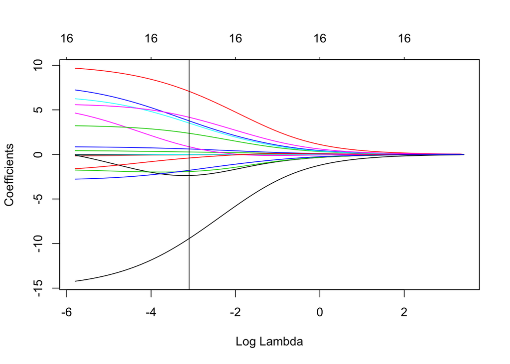

```r
x = model.matrix(y~.-pastideas-votes-comments, crowd)
fit.ridge = glmnet(x[train,], crowd$y[train], family="binomial", alpha=0)
fit.cv.ridge = cv.glmnet(x[train,], crowd$y[train], family="binomial", alpha=0)
plot(fit.ridge, xvar = "lambda")
abline(v=log(fit.cv.ridge$lambda.min))
```

```r
predict(fit.ridge, x[!train,], s=fit.cv.ridge$lambda.min, type="coef")
```

```
## 18 x 1 sparse Matrix of class "dgCMatrix"
##                       1
## (Intercept) -2.27326470
## (Intercept)  .
## month       -0.01188653
## diversity   -0.04575842
## pastaccept   0.27207939
## commentsC    0.60824462
## age         -0.02183500
## X1           0.86078921
## X2          -2.37097967
## X3           7.07447495
## X4           2.36964633
## X5           3.76561920
## X6           3.51686708
## X7           4.16697642
## X8          -9.44316202
## X9          -0.40460131
## X10         -1.92259267
## X11         -1.78605194
```

```r
phat = predict(fit.ridge, x[!train,], s=fit.cv.ridge$lambda.min, type="response")
auc(crowd$y[!train], as.vector(phat))
```

```
## [1] 0.6216537
```

# Ridge (All variables)

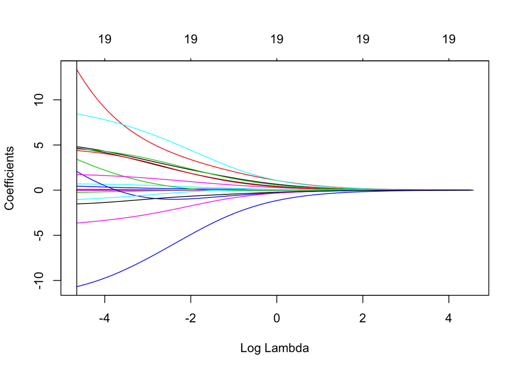

```r
x = model.matrix(y~., crowd)
fit.ridge = glmnet(x[train,], crowd$y[train], family="binomial", alpha=0)
fit.cv.ridge = cv.glmnet(x[train,], crowd$y[train], family="binomial", alpha=0)
plot(fit.ridge, xvar = "lambda")
abline(v=log(fit.cv.ridge$lambda.min))
```

```r
predict(fit.ridge, x[!train,], s=fit.cv.ridge$lambda.min, type="coef")
```

```
## 21 x 1 sparse Matrix of class "dgCMatrix"
##                        1
## (Intercept)  -2.50727924
## (Intercept)   .
## month        -0.02669448
## diversity     0.10248379
## pastideas    -0.25711721
## pastaccept    0.44205242
## commentsC     0.68486162
## age          -0.01536523
## votes         4.80917909
## comments     13.35515901
## X1            3.41647702
## X2            2.06911465
## X3            8.44302139
## X4            1.71443310
## X5            4.65937903
## X6            4.38478067
## X7            4.54908799
## X8          -10.68460666
## X9           -1.04087589
## X10          -3.64371287
## X11          -1.52682574
```

```r
phat = predict(fit.ridge, x[!train,], s=fit.cv.ridge$lambda.min, type="response")
auc(crowd$y[!train], as.vector(phat))
```

```
## [1] 0.7434557
```

# Lasso (Contributor+Content)

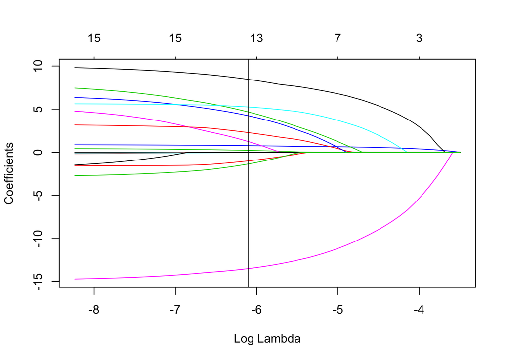

```r
x = model.matrix(y~.-pastideas-votes-comments, crowd)
fit.lasso = glmnet(x[train,], crowd$y[train], family="binomial", alpha=1)
fit.cv.lasso = cv.glmnet(x[train,], crowd$y[train], family="binomial", alpha=1)
plot(fit.lasso, xvar = "lambda")
abline(v=log(fit.cv.lasso$lambda.min))
```

```r
predict(fit.lasso, x[!train,], s=fit.cv.lasso$lambda.min, type="coef")
```

```
## 18 x 1 sparse Matrix of class "dgCMatrix"
##                        1
## (Intercept)  -2.32403630
## (Intercept)   .
## month        -0.01032894
## diversity     .
## pastaccept    0.21975400
## commentsC     0.76724380
## age          -0.03896970
## X1            1.23564641
## X2            .
## X3            8.44765941
## X4            2.27869388
## X5            4.66389440
## X6            4.22621109
## X7            5.24606215
## X8          -13.47517429
## X9            .
## X10          -0.99560329
## X11          -1.34968873
```

```r
phat = predict(fit.lasso, x[!train,], s=fit.cv.lasso$lambda.min, type="response")
auc(crowd$y[!train], as.vector(phat))
```

```
## [1] 0.617296
```

# Lasso (All variables)

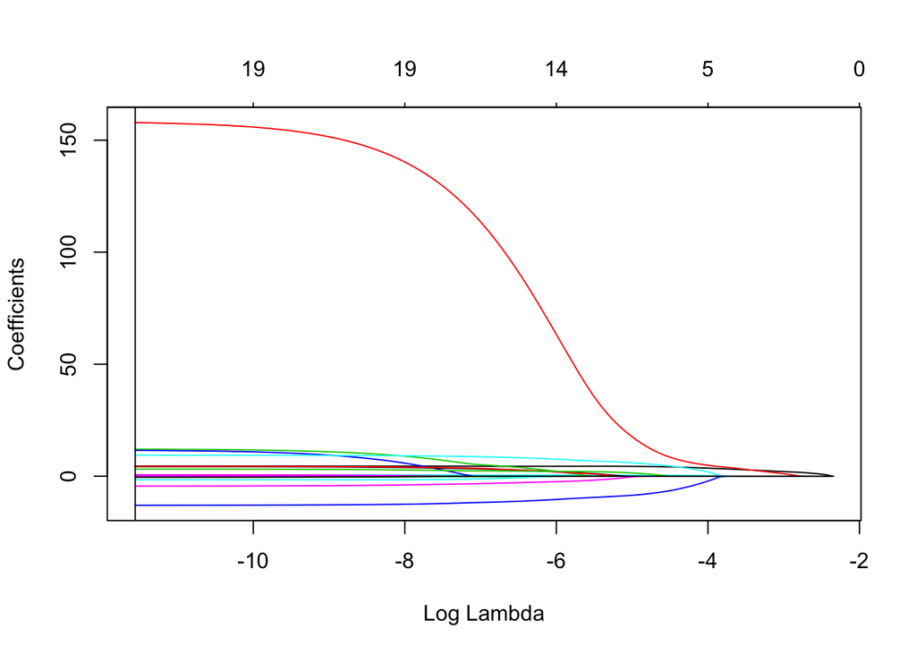

```r
x = model.matrix(y~., crowd)
fit.lasso = glmnet(x[train,], crowd$y[train], family="binomial", alpha=1)
fit.cv.lasso = cv.glmnet(x[train,], crowd$y[train], family="binomial", alpha=1)
plot(fit.lasso, xvar = "lambda")
abline(v=log(fit.cv.lasso$lambda.min))
```

```r
predict(fit.lasso, x[!train,], s=fit.cv.lasso$lambda.min, type="coef")
```

```
## 21 x 1 sparse Matrix of class "dgCMatrix"
##                        1
## (Intercept)  -2.53348396
## (Intercept)   .
## month        -0.04374840
## diversity     0.05778598
## pastideas    -0.26227840
## pastaccept    0.44834840
## commentsC     0.54173450
## age          -0.03769809
## votes         4.52802266
## comments    157.85984156
## X1           12.08821267
## X2           11.54002895
## X3            9.35188856
## X4            0.65056945
## X5            4.28853461
## X6            4.42051748
## X7            3.19049505
## X8          -12.97565365
## X9           -1.59904216
## X10          -4.41332392
## X11          -0.45844336
```

```r
phat = predict(fit.lasso, x[!train,], s=fit.cv.lasso$lambda.min, type="response")
auc(crowd$y[!train], as.vector(phat)) # test set AUC = 0.7916172
```

```
## [1] 0.7916172
```

# GAM (Contributor+Content)

```r
fit.gam = gam(y ~ s(pastaccept)+s(commentsC)+s(X1)+s(X2)+s(X3)+s(X4)+s(X5)+s(X6)+s(X7)+s(X8)+s(X9)+s(X10)+s(X11)+s(age)+s(month)+s(diversity), binomial, crowd[train,])
summary(fit.gam)
```

```
##
## Call: gam(formula = y ~ s(pastaccept) + s(commentsC) + s(X1) + s(X2) +
##     s(X3) + s(X4) + s(X5) + s(X6) + s(X7) + s(X8) + s(X9) + s(X10) +
##     s(X11) + s(age) + s(month) + s(diversity), family = binomial,
##     data = crowd[train, ])
## Deviance Residuals:
##     Min      1Q  Median      3Q     Max
## -1.7389 -0.4004 -0.3481 -0.2886  2.6990
##
## (Dispersion Parameter for binomial family taken to be 1)
##
##     Null Deviance: 1981.577 on 3505 degrees of freedom
## Residual Deviance: 1709.904 on 3440.999 degrees of freedom
## AIC: 1839.905
##
## Number of Local Scoring Iterations: 13
##
## Anova for Parametric Effects
##                 Df  Sum Sq Mean Sq F value    Pr(>F)
## s(pastaccept)    1    8.29  8.2924  9.4976  0.002074 **
## s(commentsC)     1   18.22 18.2228 20.8713 5.084e-06 ***
## s(X1)            1    7.84  7.8412  8.9808  0.002748 **
## s(X2)            1    6.75  6.7528  7.7342  0.005448 **
## s(X3)            1   16.90 16.9011 19.3574 1.117e-05 ***
## s(X4)            1    3.43  3.4318  3.9305  0.047497 *
## s(X5)            1    3.65  3.6475  4.1776  0.041038 *
## s(X6)            1    1.05  1.0534  1.2065  0.272096
## s(X7)            1    0.62  0.6178  0.7076  0.400298
## s(X8)            1   21.64 21.6377 24.7825 6.733e-07 ***
## s(X9)            1    0.18  0.1760  0.2016  0.653468
## s(X10)           1    0.29  0.2888  0.3308  0.565254
## s(X11)           1    1.94  1.9373  2.2189  0.136425
## s(age)           1    0.86  0.8642  0.9898  0.319869
## s(month)         1    0.39  0.3852  0.4411  0.506618
## s(diversity)     1    0.00  0.0000  0.0000  0.997983
## Residuals     3441 3004.35  0.8731
## ---
## Signif. codes:  0 '***' 0.001 '**' 0.01 '*' 0.05 '.' 0.1 ' ' 1
##
## Anova for Nonparametric Effects
##               Npar Df Npar Chisq    P(Chi)
## (Intercept)
## s(pastaccept)       3      2.451 0.4842623
## s(commentsC)        3      3.761 0.2883897
## s(X1)               3     12.539 0.0057468 **
## s(X2)               3      3.352 0.3405059
## s(X3)               3      2.293 0.5138894
## s(X4)               3      1.813 0.6121532
## s(X5)               3      1.886 0.5964764
## s(X6)               3      3.788 0.2853057
## s(X7)               3     10.703 0.0134467 *
## s(X8)               3     20.115 0.0001607 ***
## s(X9)               3      3.271 0.3516799
## s(X10)              3     12.736 0.0052440 **
## s(X11)              3      3.060 0.3825605
## s(age)              3     11.810 0.0080607 **
## s(month)            3      2.461 0.4823358
## s(diversity)        3     91.085 < 2.2e-16 ***
## ---
## Signif. codes:  0 '***' 0.001 '**' 0.01 '*' 0.05 '.' 0.1 ' ' 1
```

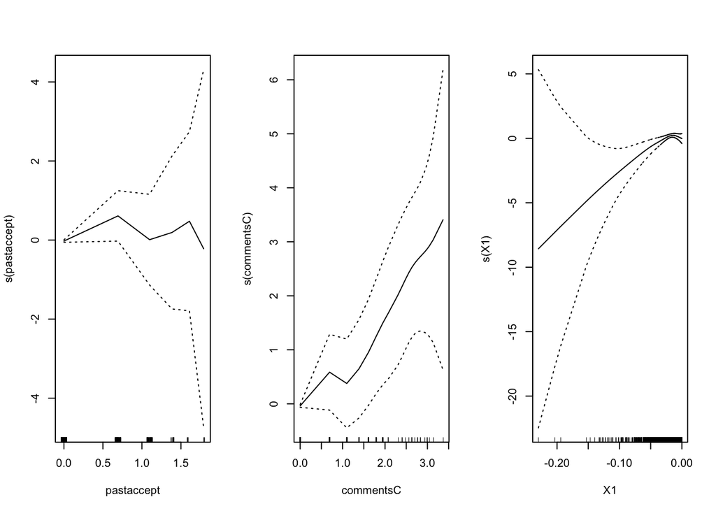

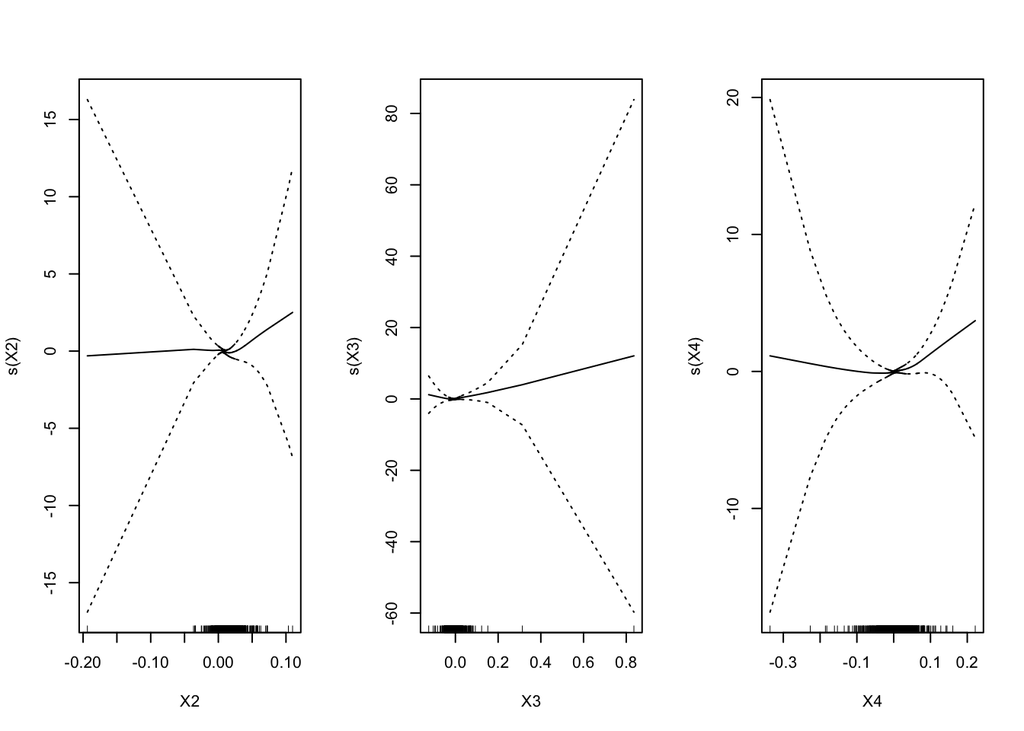

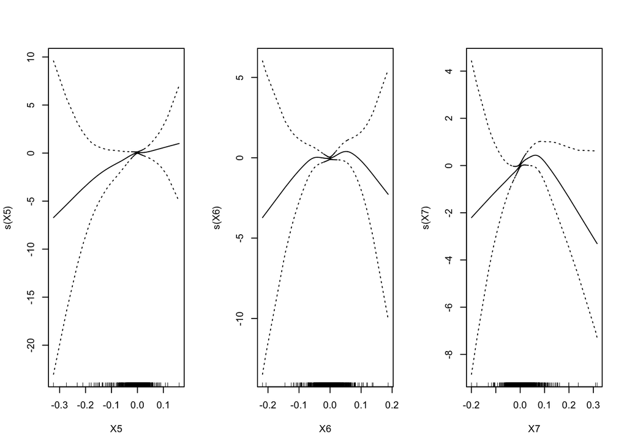

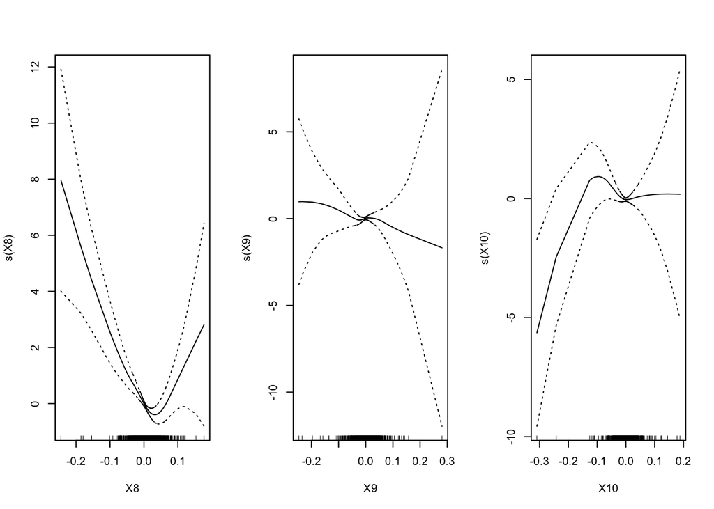

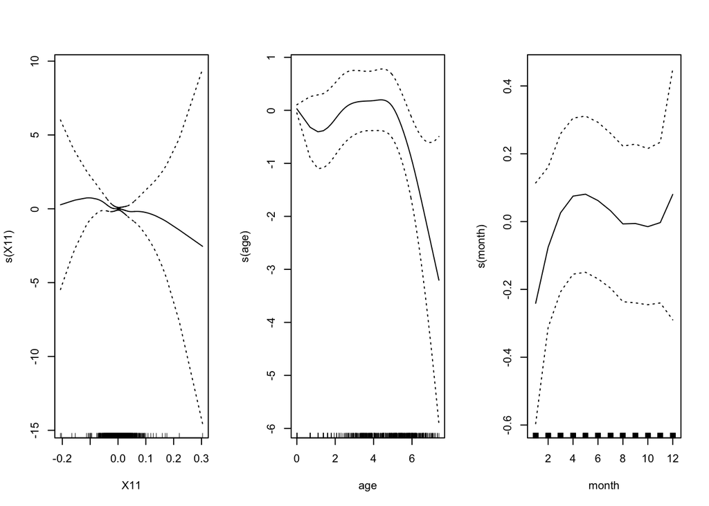

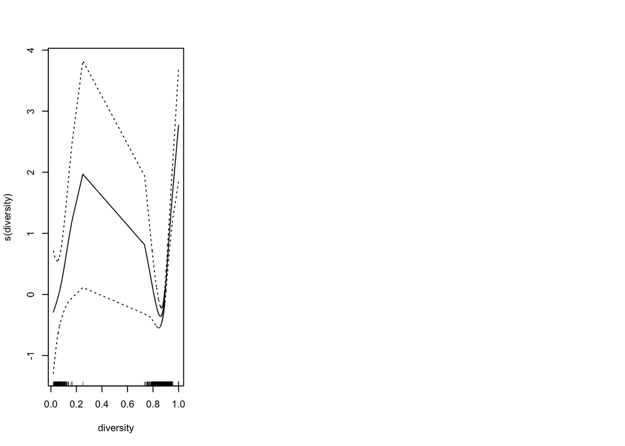

```r
par(mfrow=c(1,3))
plot(fit.gam, se=T)
```

```r
par(mfrow=c(1,1))
phat = predict(fit.gam, crowd[!train,], type="response")
auc(crowd$y[!train], phat)
```

```
## [1] 0.6996955
```

# GAM (All variables)

```r
fit.gam = gam(y ~ ., binomial, crowd[train,])
summary(fit.gam)
```

```
##
## Call: gam(formula = y ~ ., family = binomial, data = crowd[train, ])
## Deviance Residuals:
##     Min      1Q  Median      3Q     Max
## -8.4904 -0.3568 -0.3143 -0.2669  2.8140
##
## (Dispersion Parameter for binomial family taken to be 1)
##
##     Null Deviance: 1981.577 on 3505 degrees of freedom
## Residual Deviance: 1469.511 on 3486 degrees of freedom
## AIC: 1509.511
##
## Number of Local Scoring Iterations: 10
##
## Anova for Parametric Effects
##              Df     Sum Sq    Mean Sq F value Pr(>F)
## month         1 1.0000e+00 1.0000e+00       0      1
## diversity     1 0.0000e+00 0.0000e+00       0      1
## pastideas     1 0.0000e+00 0.0000e+00       0      1
## pastaccept    1 2.0000e+00 2.0000e+00       0      1
## commentsC     1 8.0000e+00 8.0000e+00       0      1
## age           1 0.0000e+00 0.0000e+00       0      1
## votes         1 5.1000e+01 5.1000e+01       0      1
## comments      1 8.7000e+01 8.7000e+01       0      1
## X1            1 0.0000e+00 0.0000e+00       0      1
## X2            1 0.0000e+00 0.0000e+00       0      1
## X3            1 9.0000e+00 9.0000e+00       0      1
## X4            1 1.0000e+00 1.0000e+00       0      1
## X5            1 1.0000e+00 1.0000e+00       0      1
## X6            1 1.0000e+00 1.0000e+00       0      1
## X7            1 1.0000e+00 1.0000e+00       0      1
## X8            1 1.5000e+01 1.5000e+01       0      1
## X9            1 0.0000e+00 0.0000e+00       0      1
## X10           1 1.0000e+00 1.0000e+00       0      1
## X11           1 0.0000e+00 0.0000e+00       0      1
## Residuals  3486 4.5036e+15 1.2919e+12
```

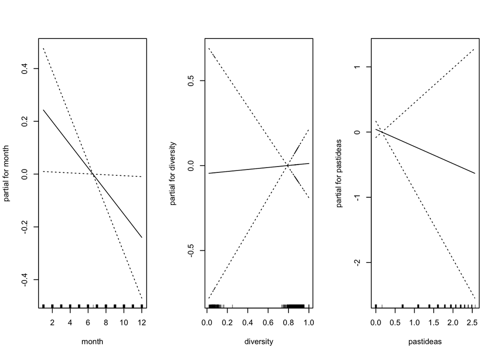

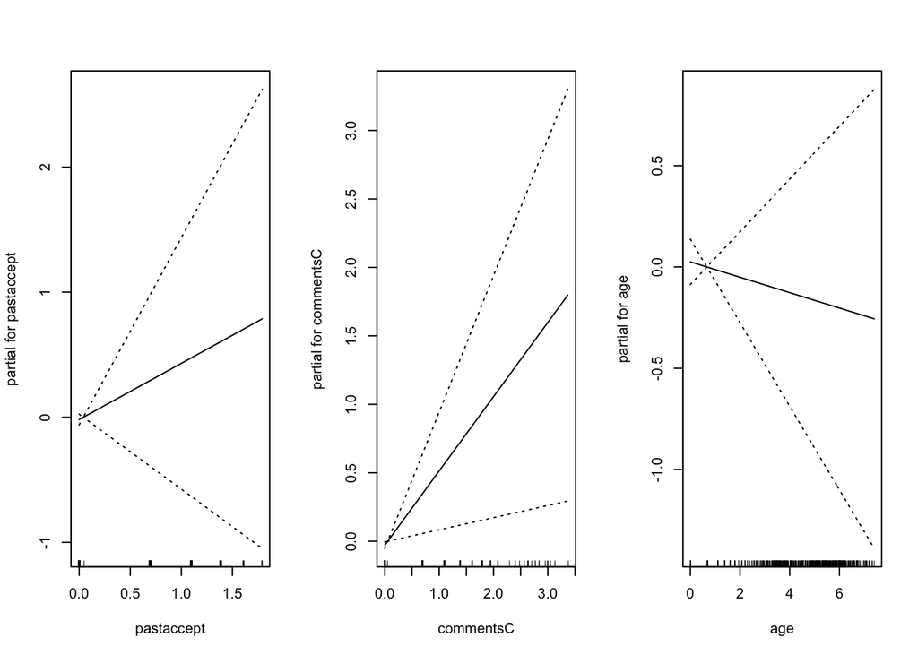

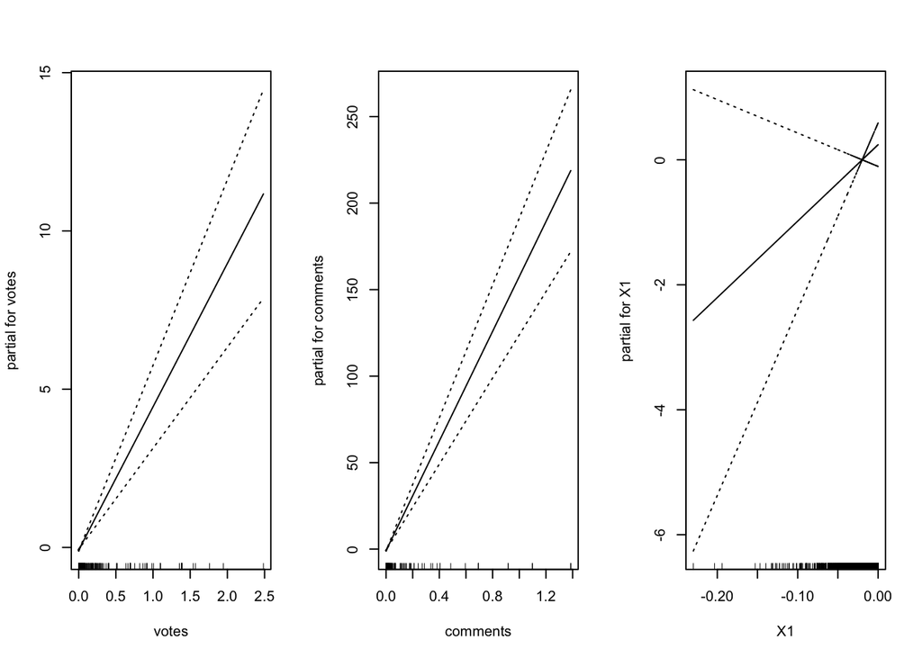

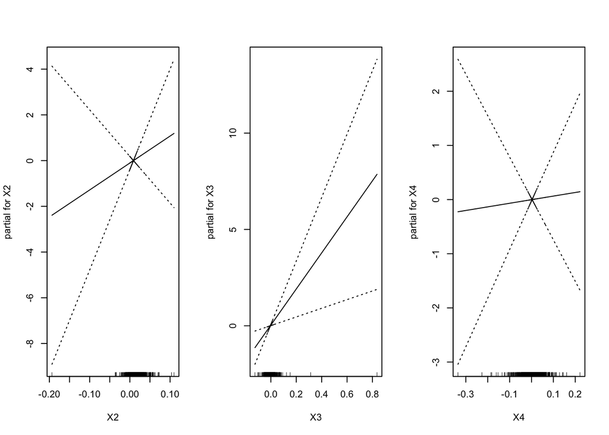

```r
par(mfrow=c(1,3))
plot(fit.gam, se=T)
```